# Biostatistical Computing, PHC 6068

R function

Zhiguang Huo (Caleb)

Monday August 28, 2017

# Why do we need functions

- If you repeat a procedure more than 2 times, you should consider make it as a function.
  - save your work in the future.
  - avoid mistakes.

# Component of a R function

- All R functions have three parts:
  - body(), the code inside the function
  - formals(), list of arguments which controls how you can call the function.
  - environment(), the map of the location of the function’s variables.

```r
cubic <- function(x){
  return(x^3)
}
body(cubic)
```

```
## {
##     return(x^3)
## }
```

```r
formals(cubic)
```

[output not shown]

```r
environment(cubic)
```

```
## <environment: R_GlobalEnv>
```

# Primitive functions

- Primitive funcitons are exceptions to the rule.
- Primitive funcitons, like sum(), call C code directly .Primitive() and contain no R code.
- Primitive funcitons are only in the base package, they can be more efficient.

```r
sum
```

```
## function (..., na.rm = FALSE)  .Primitive("sum")
```

```r
body(sum)
```

[output not shown]

```r
formals(sum)
```

[output not shown]

```r
environment(sum)
```

[output not shown]

# Example - Odds Ratio Function

- Suppose we want to write a function that calculates the odds ratio $\theta$ of a 2 x 2 contingency table and the asymptotic confidence interval for $\theta$.

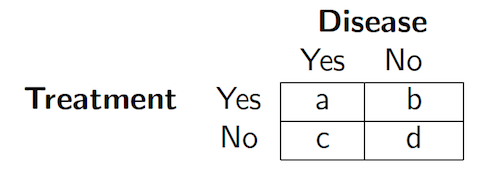

- Sample odds ratio,
  $$\hat{\theta}=\frac{ad}{bc}$$
- The asymptotic standard error for $log(\hat{\theta})$ is
  $$SE(log\hat{\theta})=\sqrt{\frac{1}{a}+\frac{1}{b}+\frac{1}{c}+\frac{1}{d}}$$
- The asymptotic 100(1-$\alpha$)% confidence interval for $log\hat{\theta}$ is,
  $$log\hat{\theta} \pm z_{\alpha/2}SE(log\hat{\theta})$$
- Exponentiate the upper and lower bounds to get a confidence interval for $\theta$.

# Example - Odds Ratio Function

- Consider the following data that describes the relationship between myocardial infarction and aspirin use (Agresti 1996).

```r
odds.ratio <- function(X){
  result <- X[1,1]*X[2,2]/(X[1,2]*X[2,1])
  return(result)
}

X <- matrix(c(189, 104, 10845, 10933), nrow=2,
            dimnames=list(Treatment=c("Placebo","Aspirin"),
                          "Myocardial Infarction"=c("Yes", "No")))
X
```

```
##          Myocardial Infarction
## Treatment Yes    No
##   Placebo 189 10845
##   Aspirin 104 10933
```

```r
odds.ratio(X)
```

```
## [1] 1.832054
```

# Returning Objects

- Often we will want a function to return an object that can be assigned. Two functions for returning objects are return() and invisible().
- The return() function prints and returns its arguments.
- If the end of a function is reached without calling return(), the value of the last evaluated expression is returned and outputted.
- You can also omit {} if there is only one line for the body

```r
odds.ratio0 <- function(X){
  result <- X[1,1]*X[2,2]/(X[1,2]*X[2,1])
  return(result)
}
odds.ratio0(X)
```

```
## [1] 1.832054
```

```r
odds.ratio1 <- function(X){
  X[1,1]*X[2,2]/(X[1,2]*X[2,1])
}
odds.ratio1(X)
```

```
## [1] 1.832054
```

```r
odds.ratio2 <- function(X)
  X[1,1]*X[2,2]/(X[1,2]*X[2,1])

odds.ratio2(X)
```

```
## [1] 1.832054
```

```r
## here nothing is returned
OR <- odds.ratio2(X)
OR
```

```
## [1] 1.832054
```

# Returning Objects 2

- The invisible() function is useful when we want a function to return values which can be assigned, but which do not print when they are not assigned.

```r
odds.ratio3 <- function(X){
  result <- X[1,1]*X[2,2]/(X[1,2]*X[2,1])
  invisible(result)
}
odds.ratio3(X)
## here nothing is returned
OR <- odds.ratio3(X)
OR
```

```
## [1] 1.832054
```

# Return multiple variables

- A list is often a good tool for returning multiple objects.

```r
odds.ratio <- function(X, conf.level=0.95){
  OR <- X[1,1]*X[2,2]/(X[1,2]*X[2,1])
  logOR.SE <- sqrt(sum(1/X))

  alpha <- 1 - conf.level
  CI.lower <- exp(log(OR) - qnorm(1 - alpha/2)*logOR.SE)
  CI.upper <- exp(log(OR) + qnorm(1 - alpha/2)*logOR.SE)
  # qnorm returns the quantiles of a Gaussian distribution.

  out <- list(OR=OR, CI=c(CI.lower, CI.upper), conf.level=conf.level)
  return(out)
}
odds.ratio(X)
```

```
## $OR
## [1] 1.832054
##
## $CI
## [1] 1.440042 2.330780
##
## $conf.level
## [1] 0.95
```

```r
odds.ratio(X)$OR
```

```
## [1] 1.832054
```

# tracking progress of a function

- The cat() and print() functions can be used to output results;
  - the cat() function gives more control over the appearance of the output.

```r
odds.ratio <- function(X, conf.level=0.95){
  cat("calculating odds ratio...","\n")
  OR <- X[1,1]*X[2,2]/(X[1,2]*X[2,1])
  logOR.SE <- sqrt(sum(1/X))

  cat("calculating confidence interval...","\n")
  alpha <- 1 - conf.level
  CI.lower <- exp(log(OR) - qnorm(1 - alpha/2)*logOR.SE)
  CI.upper <- exp(log(OR) + qnorm(1 - alpha/2)*logOR.SE)

  cat("done, returning output...","\n")
  out <- list(OR=OR, CI=c(CI.lower, CI.upper), conf.level=conf.level)
  return(out)
}
out <- odds.ratio(X)
```

```
## calculating odds ratio...
## calculating confidence interval...
## done, returning output...
```

# Verifying Arguments

- If you are writing a function for others to use it is often a good idea to include code that verifies that the appropriate arguments were entered.
- If an argument value is not valid we want to stop executing the expression and return an error message.
  - missing(): Can be used to test whether a value was specified as an argument to a function; returns TRUE if a value is not specified and FALSE if a value is specified.
  - stop(): Stop execution of the current expression and prints an error.
  - warning(): Generate a warning message.
  - message(): Generate a diagnostic message.
  - stopifnot(): If any of the arguments are not all TRUE then stop() is called and an error message is produced that indicates the first element of the argument list that is not TRUE.
  - stop() allows us to provide an informative error message, while stopifnot() requires less code.

# examples for verifying arguments

```r
odds.ratio <- function(X, conf.level=0.95){
  stopifnot(!missing(X), is.matrix(X),dim(X)==c(2,2),X>0)

  cat("calculating odds ratio...","\n")
  OR <- X[1,1]*X[2,2]/(X[1,2]*X[2,1])
  logOR.SE <- sqrt(sum(1/X))

  cat("calculating confidence interval...","\n")
  alpha <- 1 - conf.level
  CI.lower <- exp(log(OR) - qnorm(1 - alpha/2)*logOR.SE)
  CI.upper <- exp(log(OR) + qnorm(1 - alpha/2)*logOR.SE)

  cat("done, returning output...","\n")
  out <- list(OR=OR, CI=c(CI.lower, CI.upper), conf.level=conf.level)
  return(out)
}
out <- odds.ratio(X)
```

```
## calculating odds ratio...
## calculating confidence interval...
## done, returning output...
```

# Every operation is a function call (optional)

- infix operators: +, -, *, /

```r
x <- 10; y <- 5;
x + y
```

```
## [1] 15
```

```r
'+'(x, y)
```

```
## [1] 15
```

- Control flow operators: for, if while

```r
for(i in 1:2) cat(i,' ')
```

```
## 1  2
```

```r
'for'(i, 1:2, cat(i,' '))
```

```
## 1  2
```

- Subsetting operator

```r
x <- 1:10; x[3]
```

```
## [1] 3
```

```r
'['(x,3)
```

```
## [1] 3
```

# Function arguments – default value

- default argument of a function can be defined in the function formals

```r
f <- function(arg, brg=10)
  list(arg = arg, brg = brg)
str(f(arg=2, brg=10))
```

```
## List of 2
##  $ arg: num 2
##  $ brg: num 10
```

```r
str(f(arg=2))
```

```
## List of 2
##  $ arg: num 2
##  $ brg: num 10
```

- revisit = and <-
  - = can be used for assigning value and specifying function argument
  - <- can only be used for assigning value.

# Function arguments

- How to specify function arguments
  - by position
  - complete name
  - partial name.
- Arguments match order
  1. first by exact name (perfect matching),

```r
f <- function(arg, brg=10)
  list(arg = arg, brg = brg)
str(f(arg=2, brg=10))
```

```
## List of 2
##  $ arg: num 2
##  $ brg: num 10
```

```
2. then by prefix matching,
```

```r
f <- function(arg, brg=10)
  list(a = arg, b = brg)
str(f(b=10, ar=2))
```

```
## List of 2
##  $ a: num 2
##  $ b: num 10
```

```
3. finally by position matching
```

```r
f <- function(arg, brg=10)
  list(a = arg, b = brg)
str(f(2, 10))
```

```
## List of 2
##  $ a: num 2
##  $ b: num 10
```

# function calling habits

- good calls

```r
mean(1:10); mean(1:10, trim = 0.05)
```

```
## [1] 5.5
```

```
## [1] 5.5
```

- overkill

```r
mean(x=1:10)
```

```
## [1] 5.5
```

- confusing

```r
mean(1:10, n = T); mean(1:10, , FALSE); mean(1:10, 0.05); mean(, TRUE, x = c(1:10, NA))
```

```
## [1] 5.5
```

```
## [1] 5.5
```

```
## [1] 5.5
```

```
## [1] 5.5
```

# calling a function given a list of arguments

- If you have a list of function arguments:
  - args <- list(1:10, na.rm=TRUE)
- How could you then send that list to mean()?
  - Need do.call()

```r
do.call(mean, list(1:10, na.rm=TRUE))
```

```
## [1] 5.5
```

```r
mean(1:10, na.rm=TRUE)
```

```
## [1] 5.5
```